# Take Home Examination

## 5. Aufgabenteil

- **a) Puntkwolke Plotten**

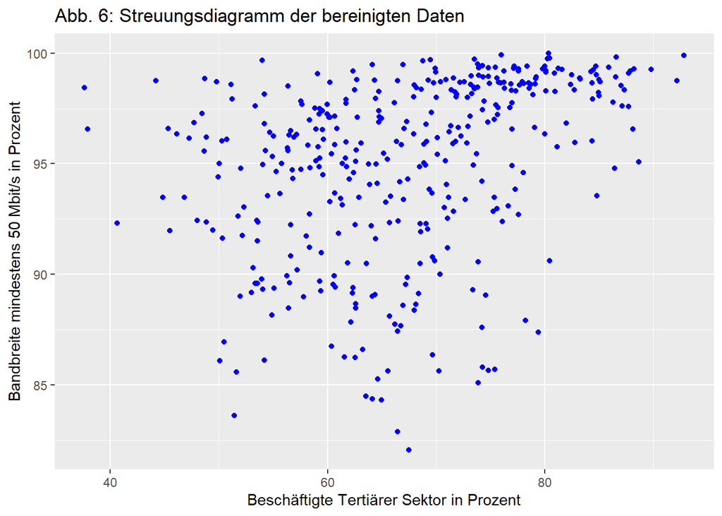

```r
# a)
ggplot(rohdaten_cleaned, aes(x = Beschaeftigte, y = Bandbreite)) +
  geom_point(color = "blue") +
  labs(title = "Abb. 6: Streuungsdiagramm der bereinigten Daten",
       x = "Beschäftigte Tertiärer Sektor in Prozent",
       y = "Bandbreite mindestens 50 Mbit/s in Prozent")
```

### Einordnung der Variablen

> Ich möchte wissen, ob es in Deutschland einen Trend gibt, dass Kreise mit einem hohen Anteil an Beschäftigten im tertiären Sektor auch einen tendenziell hohen Ausbau der Bandbreite bedeutet.  
> Demnach ist die Bandbreite meine abhängige Variable .

### Interpretation der Punktwolke

> - **Anordnung der Punkte**:
> - Die Punkte zeigen, dass es eine leichte Tendenz gibt, dass Kreise mit einem hohen Anteil an Beschäftigten im tertiären Sektor auch einen tendenziell hohen Ausbau der Bandbreite haben.
> - **Cluster**:
> - Gerade im hohen Prozentbereich bei dem Breitbandausbau gibt es eine hohe Dichte an Punkten. Das bedeutet, dass es viele Kreise gibt, die einen hohen Anteil an Beschäftigten im tertiären Sektor über überdurchschnittliche Bandbreite verfügen.  
>   Dies trifft aber nicht auf die unteren Prozente zu, gerade hier sind die Punkte sehr verstreut und es gibt keine klare aussage.
> - **Fazit**
> - Es gibt **keine** klare lineare Beziehung zwischen den beiden Variablen jedoch gibt es einen Aufwärtstrend, welcher sich an die 100 % Breitbandausbau annähert.

## 6. Aufgabenteil

- **a) Korrelation plotten**  
  Korrelationskoeffizient zwischen Bandbreite und Beschäftigten

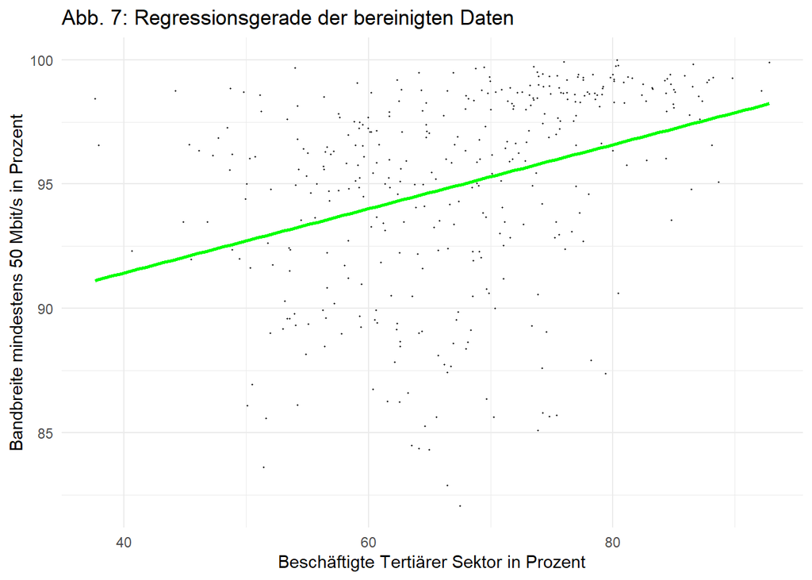

```r
ggplot(rohdaten_cleaned, aes(x = Beschaeftigte, y = Bandbreite)) +
  geom_point(size = 0.2, alpha = 0.8, na.rm = TRUE) +
  geom_smooth(method = "lm", se = FALSE, color = "green") +
  labs(
    title = "Abb. 7: Regressionsgerade der bereinigten Daten",
    x = "Beschäftigte Tertiärer Sektor in Prozent",
    y = "Bandbreite mindestens 50 Mbit/s in Prozent"
  ) +
  theme_minimal()
```

### Interpretation der Korrelation

> Das Modell kann die Daten nicht erklären. Eine Homoskedastizität ist nicht gegeben, da die Residuen nicht gleichmäßig verteilt sind und einen hohen und ungleichmäßigen Streuungsbereich aufweisen. Somit ist eine Regression nicht sinnvoll, da die Daten nicht linear sind und die Residuen nicht gleichmäßig verteilt sind.

## 7. Aufgabenteil

- **a) Korrelation berechnen**  
  Lineares Modell zwischen Bandbreite und Beschäftigten erstellen
- **b) R², Residuale Standardabweichung und P-Werte der Koeffizienten abspeichern und printen**

```r
# a)
model <- lm(Bandbreite ~ Beschaeftigte, data = rohdaten_cleaned)

# b)
summary_model <- summary(model)

r_squared <- summary_model$r.squared
adjusted_r_squared <- summary_model$adj.r.squared

rse <- summary_model$sigma

p_values <- summary_model$coefficients[, 4]

# Print the results
# Ausgabe der Ergebnisse
cat("R-Quadrat: ", r_squared, "\n")
```

```
## R-Quadrat:  0.1184023
```

```r
cat("Residuale Standardabweichung: ", rse, "\n")
```

```
## Residuale Standardabweichung:  3.809914
```

```r
cat("P-Werte der Koeffizienten:",p_values,"\n")
```

```
## P-Werte der Koeffizienten: 1.522802e-218 5.299159e-12
```

> **R²:** Gibt die generelle Modellgüte an.  
> Ein Wert von ~0,12 deutet auf ein schwach erklärendes Modell hin. Das bedeutet:  
> - Es gibt nur eine sehr schwache Beziehung zwischen den erklärenden Variablen und der Zielvariable.  
> - Das Modell ist möglicherweise nicht ausreichend, um zuverlässige Vorhersagen zu treffen.  
> - Die Beziehung zwischen den Variablen nicht linear sein.

> **Standardabweichung der Residuen:** Zeigt, wie genau das Modell die Daten beschreibt eine Abweichung von 3.8%

> **P-Werte:** Bewerten die Signifikanz der einzelnen Modellparameter  
> Diese Werte sind extrem klein (weit unter dem üblichen Signifikanzniveau von 0,05). Das bedeutet:  
> -Die unabhängigen Variablen haben einen signifikanten Einfluss auf die abhängige Variable.  
> -Es ist sehr unwahrscheinlich, dass diese Ergebnisse zufällig zustande gekommen sin

## 9. Aufgabenteil

- **a) Shapefile wird in R-Variable abgespeichert**
- **b) Beschriftung der Bundesländer als Dictonary anlegen**

```r
# a)
shapefile <- sf::st_read("shp/VZ250_GEM.shp")
# b)
beschriftung_bundeslaender <- c(
  "01" = "Schleswig-Holstein",
  "02" = "Hamburg",
  "03" = "Niedersachsen",
  "04" = "Bremen",
  "05" = "Nordrhein-Westfalen",
  "06" = "Hessen",
  "07" = "Rheinland-Pfalz",
  "08" = "Baden-Wuettemberg",
  "09" = "Bayern",
  "10" = "Saarland",
  "11" = "Berlin",
  "12" = "Brandenburg",
  "13" = "Mecklenburg-Vorpommern",
  "14" = "Sachsen",
  "15" = "Sachsen-Anhalt",
  "16" = "Thüringen"
)
```

- **c) R-Variable nach Gemeinden Gruppiert abspeichern**
- **d) Shapefile nach Bundesländern Gruppieren nach ARS**
- **e) Daten verknüpfen (Raumbezug herstellen)**
- **f) Identifizieren der fehlenden Kreise um auf der Karte die Ausreißer zu benennen**

```r
# c)
kreise <- shapefile %>%
  dplyr::group_by(ARS_K, GEN_K) %>%
  dplyr::summarize(Gemeinden = n())

# d)
bundeslaender <- shapefile %>%
  dplyr::mutate(Bundesland = recode(substr(ARS_K, 1, 2), !!!beschriftung_bundeslaender)) %>%
  dplyr::group_by(Bundesland) %>%
  dplyr::summarize(Gemeinden = n())

# e)
data_cleaned_geom_kreise <- merge(x = kreise, y = rohdaten_cleaned, by.x = "ARS_K", by.y = "ID")

# f)
fehlende_kreise <- setdiff(kreise$ARS_K, data_cleaned_geom_kreise$ARS_K)
fehlende_kreise_df <- kreise[kreise$ARS_K %in% fehlende_kreise, ]
```

## 10. Aufgabenteil

- **a) Differenz zwischen Bandbreite und Beschäftigten berechnen**
- **b) Karte der Differenz plotten**

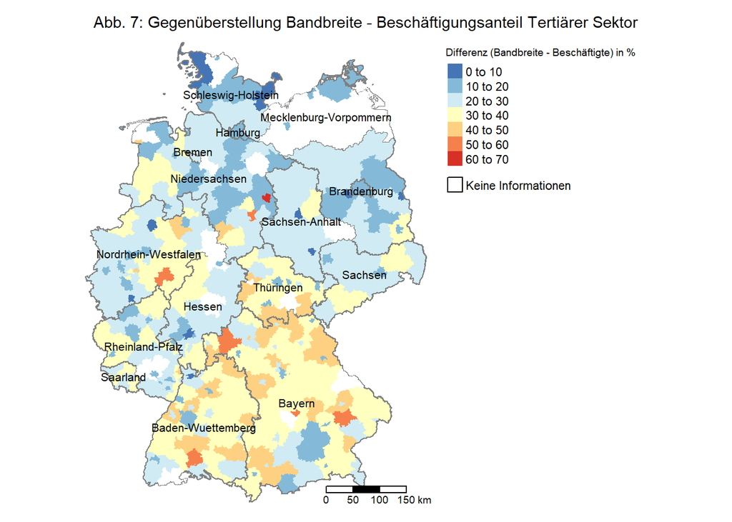

```r
# a)
data_cleaned_geom_kreise_01 <- data_cleaned_geom_kreise %>%
  mutate(Differenz = Bandbreite - Beschaeftigte)

# b)
map <- tm_shape(data_cleaned_geom_kreise_01) +
  tm_fill(
    "Differenz",
    title = "Differenz (Bandbreite - Beschäftigte) in %",
    palette = "-RdYlBu"
  ) +
  tm_shape(bundeslaender) +
  tm_borders(col = 'grey50') +
  tm_scale_bar(
    width = 0.18,
    position = c("RIGHT", "BOTTOM"),
    text.size = 0.6,
    color.dark = "black",
    color.light = "white",
    just = c("RIGHT", "BOTTOM"),
    lwd = 1
  ) +
  tm_layout(
    frame = FALSE,
    main.title = "Abb. 7: Gegenüberstellung Bandbreite - Beschäftigungsanteil Tertiärer Sektor",
    main.title.position = "center",
    main.title.size = 0.9,
    title.position = c("center", "top"),
    legend.title.size = 0.8,
    legend.outside = TRUE,
    title.snap.to.legend = FALSE
  ) +
  tm_shape(fehlende_kreise_df) +
  tm_fill(col = "white") +
  tm_add_legend(type = "fill", labels = "Keine Informationen", col = "white") +
  tm_shape(sf::st_centroid(bundeslaender)) +
  tm_text(
    "Bundesland",
    remove.overlap = TRUE,
    size = 0.65,
    col = "black",
    fontface = "bold",
    shadow = FALSE
  )
tmap_mode("plot")
invisible(print(map))
```

### Interpretation der Karte

> - Wir können sehen das es keinen Kreis gibt, wo es Prozentual mehr beschäftigte im tertiären Sektor arbeiten als die Bandbreite über 50 mb/s gewährleistet sind.
> - Nach Süden hin nimmt die Differenz zu, dort gibt es mehr gutes Internet, auch wenn es weniger Beschäftigte im tertiären Sektor gibt.
> - Im Ost-West Vergleich gibt es keine klare Tendenz

## 11. Aufgabenteil

- **a) Lineare Regression durchführen**
- **b) Klassen nach Sturges definieren**
- **c) Klassenbeschriftungen definieren**
- **d) Karte der Residuen plotten**

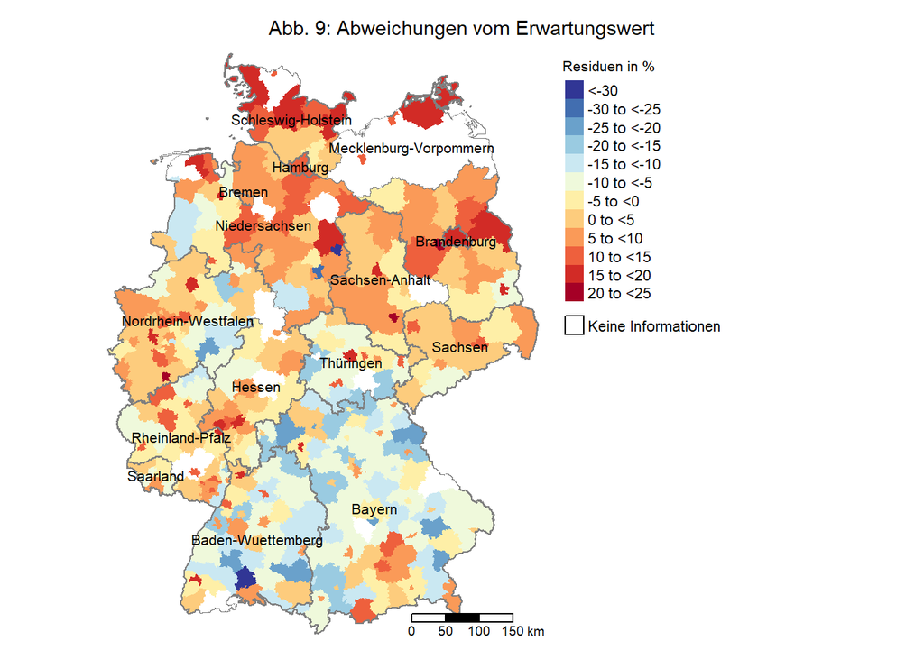

```r
# a)
model <- lm(Beschaeftigte ~ Bandbreite, data = data_cleaned_geom_kreise)
data_cleaned_geom_kreise$residuals <- as.numeric(residuals(model))


# b)
residuals_class <- classInt::classIntervals(
  data_cleaned_geom_kreise$residuals,
  n = nclass.Sturges(data_cleaned_geom_kreise$residuals),
  style = 'pretty'
)

# c)
breaks <- residuals_class$brks
labels <- c(
  paste0("<", breaks[2]),
  paste0(breaks[-c(1, length(breaks))], " to <", breaks[-c(1, 2)]),
  paste0(">", breaks[length(breaks) - 1])
)

# d)
res_map <- tm_shape(data_cleaned_geom_kreise) +
  tm_fill(
    "residuals",
    breaks = residuals_class$brks,
    title = "Residuen in %",
    labels = labels,
    midpoint = NA,
    palette = "-RdYlBu"
  ) +
  tm_shape(bundeslaender) +
  tm_borders(col = 'grey50') +
  tm_scale_bar(
    width = 0.18,
    position = c("RIGHT", "BOTTOM"),
    text.size = 0.6,
    color.dark = "black",
    color.light = "white",
    just = c("RIGHT", "BOTTOM"),
    lwd = 1
  ) +
  tm_layout(
    frame = FALSE,
    main.title = "Abb. 9: Abweichungen vom Erwartungswert",
    main.title.position = "center",
    main.title.size = 0.9,
    title.position = c("center", "top"),
    legend.title.size = 0.8,
    legend.outside = TRUE,
    title.snap.to.legend = FALSE
  ) +
  tm_shape(fehlende_kreise_df) +
  tm_fill(col = "white") +
  tm_add_legend(type = "fill", labels = "Keine Informationen", col = "white") +
  tm_shape(sf::st_centroid(bundeslaender)) +
  tm_text(
    "Bundesland",
    remove.overlap = TRUE,
    size = 0.65,
    col = "black",
    fontface = "bold",
    shadow = FALSE
  )
tmap_mode("plot")
invisible(print(res_map))
```

`Abb. 9`

### Ähnlichkeiten der beiden Karten

> - Extremwerte zeichnen sich räumlich ähnlich ab
> - Nord/Süd gefälle
> - Sonst keinen weiteren zusammenhang zwischen den Karten zu erkennen.